# Question

In a deck of strange cards, there are 423 cards. Each card has an image and a color.

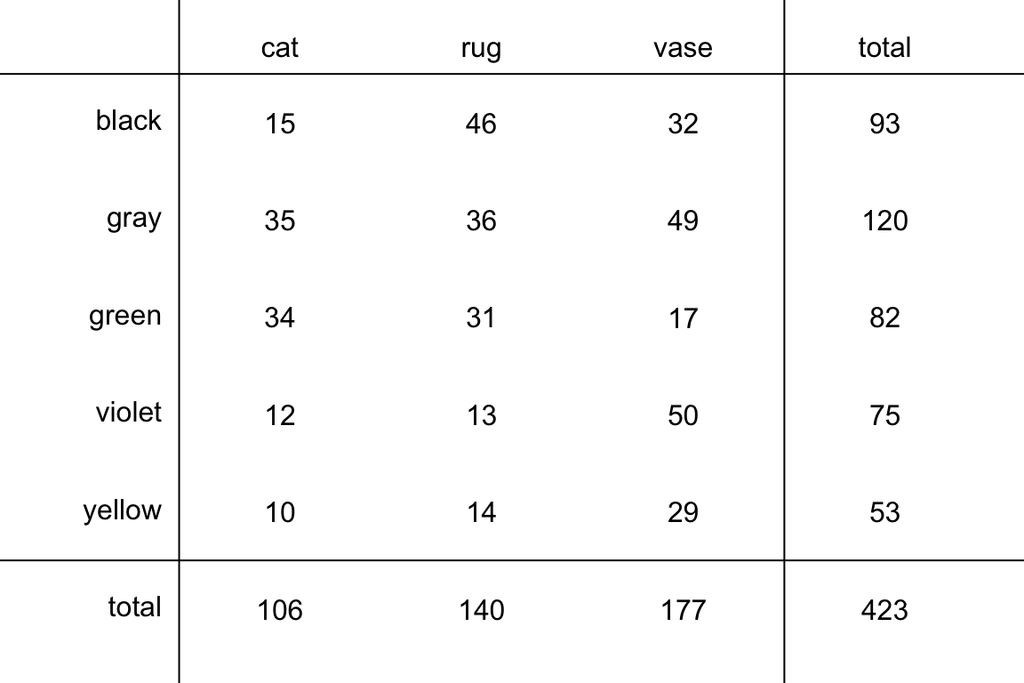

1. What is the probability a random card is a vase? ##ANSWER1##
2. What is the probability a random card is gray? ##ANSWER2##
3. What is the probability a random card is both a vase and green? ##ANSWER3##
4. What is the probability a random card is either a rug or black (or both)? ##ANSWER4##
5. What is the probability a random card is violet given it is a rug? ##ANSWER5##
6. What is the probability a random card is a cat given it is gray? ##ANSWER6##
7. Between a cat and a rug, which is more likely to be a gray? ##ANSWER7##

## Answerlist

- 0.01
- 0.25
- 0.42
- 0.58
- 0.07
- 0.13
- 0.28
- 0.77
- 0.04
- 0.26
- 0.36
- 0.46
- 0.08
- 0.11
- 0.15
- 0.44
- 0.09
- 0.21
- 0.30
- 0.35
- 0.12
- 0.16
- 0.29
- 0.41
- A cat.
- A rug.

# Solution

[video](https://vimeo.com/531915456)

The key logical terms are “[and](https://en.wikipedia.org/wiki/Logical_conjunction)”, “[or](https://en.wikipedia.org/wiki/Logical_disjunction)”, and “[given](https://en.wikipedia.org/wiki/Conditional_probability)”. Notice that I am using “given” as a shorter version of “under the condition”.

1. $P(\text{vase})=\frac{177}{423}=0.42$
2. $P(\text{gray})=\frac{120}{423}=0.28$
3. $P(\text{vase and green})=\frac{17}{423}=0.04$
4. $P(\text{rug or black})=\frac{140+93-46}{423}=0.44$
5. $P(\text{violet given rug})=\frac{13}{140}=0.09$
6. $P(\text{cat given gray})=\frac{35}{120}=0.29$
7. $P(\text{gray given cat}) = 0.33$ and $P(\text{gray given rug}) = 0.26$, so a cat is more likely to be gray than a rug is.

# Meta-information

extype: cloze exsolution: 0010|0010|1000|0001|1000|0010|10 exclozetype: schoice|schoice|schoice|schoice|schoice|schoice|schoice exname: Cards_probabilities